# 2012 NLS Data RMD

Scott Stoner

2023

## Data Import

This section covers importing lake chemistry and watershed data for the purpose of lake selection. The relevant data is first retrieved from one of the NLS 2012 csv files. Then each table is reduced to contain just the variables of interest. This table is converted into a tibble, which overwrites the original variable containing the imported data. These variables fall into two categories, watershed and water chemistry. Additional variables are included to help with ID or shed light on connections made during PCA. Important to note that there are 2 ID systems in use, UIDs (unique sample event IDs) and Site IDs (lake specific IDs). Retaining both is important to select and summarize lakes with multiple sample events later in the process. Variable names and notes are included for each imported data set.

#### Site Info

- AREA_HA (lake area, hectares)
- STATE
- SIZE_CLASS
- SITETYPE (probability or handpicked)
- ELEVATION
- FS_EW (forest service land east or west)
- DSGN12 (incorporated in the NLA2012 design framework)
- NA_L2CODE (ecoregion level 2)
- NA_L3CODE (ecoregion level 3)
- URBAN (determination based on land use)
- EVAL_NAME (lake name)
- LAKE_ORIGIN (“manmade or natural”)
- PERIM_KM (lake perimeter)
- SITESAMP (was site sampled)
- DATE_COL (date of sample collection)
- SITE_ID (id code for site 2012 version)
- VISIT_NO (visit number for site)
- UID (unique site visit id)

```r
siteinfo <- read.csv("nla2012_wide_siteinfo_08232016.csv")

siteinfo %>%
  dplyr::select(UID, SITE_ID, VISIT_NO, DATE_COL, SITETYPE, SITESAMP, DSGN12, EVAL_NAME, STATE, ELEVATION, AREA_HA, PERIM_KM, SIZE_CLASS, FS_EW, NA_L2CODE, NA_L3CODE, URBAN, LAKE_ORIGIN) %>%
  tibble::as_tibble() -> siteinfo
```

#### Watershed Data

- SITE_ID
- DOMGEOL_BSN (dominant geology)
- NLCD2006_ASSIGNEDAREA_BSN (area within basin assigned nlcd value*)
- NLCD2006_DEVELOPEDPCT_BSN (percent developed)
- NLCD2006_FORESTPCT_BSN (percent forest)
- NLCD2006_IMPERVAREA_BSN (percent impervious)
- PMEAN_BSN (mean annual precipitation in basin)[multiple precip values]
- TMEANPY_BSN (mean temperature in basin 12 months)[multiple temp values]

```r
watershed <- read.csv("nla2012_wide_watershed.csv")

watershed %>%
  dplyr::select(SITE_ID, DOMGEOL_BSN, NLCD2006_ASSIGNEDAREA_BSN, NLCD2006_DEVELOPEDPCT_BSN, NLCD2006_FORESTPCT_BSN, NLCD2006_IMPERVAREA_BSN, PMEAN_BSN, TMEANPY_BSN) %>%
  tibble::as_tibble() -> watershed
```

#### Water Chemistry Data

- UID
- NTL_RESULT (Total Nitrogen mg/L)
- PTL_RESULT (Total Phosphorus ug/L)
- PH_RESULT

```r
waterchem <- read.csv("nla2012_waterchem_wide.csv")

waterchem %>%
  dplyr::select(UID, NTL_RESULT, PTL_RESULT, PH_RESULT) %>%
  tibble::as_tibble() -> waterchem
```

## Data Merge

The selected data from the imported tables is now combined into a single table that will be used for lake selection. First a left join using the SITE_ID field to append watershed data to general site info. Then a left join is used to append the water chemistry data to each visit using the UID field. The result is output into the ‘mega_table’.

```r
siteinfo %>%
  dplyr::left_join(watershed, by = "SITE_ID") %>%
  dplyr::left_join(waterchem, by = "UID") -> mega_table
```

### Lake Selection

#### Initial Filter

This section concerns removing data (lakes) that lack sampling data. First, lakes with no sampling data are excluded, followed by lakes that were not randomly selected.

```r
mega_table %>%
  dplyr::filter(SITESAMP == "Y") %>%
  dplyr::filter(SITETYPE == "PROB") -> initial_filter_result
```

#### Multiple Sample Lakes

This section currently strips the second sample set from each lake with multiple samples. It would be preferable not to delete potentially relevant data, **section needs to be reviewed**

```r
initial_filter_result %>%
  dplyr::filter(VISIT_NO == 1) -> data_filtered
```

#### Watershed Filter

Here is where the bulk of the lake selection process happens.

List of selection conditions in order:

1. NA_L2CODE = 6.2
- The 6.2 NA Ecoregion 2 Code represents the “Western Cordillera” also known as the Northwestern Forested Mountain Region.
2. STATE = CA, OR, WA, ID, MT
- The restriction to these 5 states removes areas of Ecoregion 6.2 that are mostly in Colorado and New Mexico.
3. Possibly more later: Elevation, Size, Land Use

```r
data_filtered %>%
  dplyr::filter(NA_L2CODE == 6.2) %>%
  dplyr::filter(STATE == "CA" | STATE == "OR" | STATE == "WA" | STATE == "ID" | STATE == "MT") -> data_filtered
  data_filtered
```

```
## # A tibble: 82 x 28
##      UID SITE_ID      VISIT_NO DATE_COL SITETYPE SITESAMP DSGN12 EVAL_NAME STATE
##    <int> <chr>           <int> <chr>    <chr>    <chr>    <chr>  <chr>     <chr>
##  1  7916 NLA12_CA-103        1 8/13/20~ PROB     Y        Inclu~ French M~ CA
##  2  8483 NLA12_CA-104        1 9/11/20~ PROB     Y        Inclu~ June Lake CA
##  3  8466 NLA12_CA-107        1 9/10/20~ PROB     Y        Inclu~ Lake Alp~ CA
##  4  6559 NLA12_CA-116        1 6/12/20~ PROB     Y        Inclu~ Castle L~ CA
##  5  7989 NLA12_CA-123        1 8/15/20~ PROB     Y        Inclu~ Scotts L~ CA
##  6  7563 NLA12_CA-128        1 7/31/20~ PROB     Y        Inclu~ Plaskett~ CA
##  7  6596 NLA12_CA-132        1 6/13/20~ PROB     Y        Inclu~ Rainbow ~ CA
##  8  7988 NLA12_CA-135        1 8/15/20~ PROB     Y        Inclu~ Caples L~ CA
##  9  8424 NLA12_CA-138        1 9/6/2012 PROB     Y        Inclu~ Pine Lake CA
## 10  7423 NLA12_CA-166        1 7/24/20~ PROB     Y        Inclu~ Eureka L~ CA
## # ... with 72 more rows, and 19 more variables: ELEVATION <dbl>, AREA_HA <dbl>,
## #   PERIM_KM <dbl>, SIZE_CLASS <chr>, FS_EW <chr>, NA_L2CODE <dbl>,
## #   NA_L3CODE <chr>, URBAN <chr>, LAKE_ORIGIN <chr>, DOMGEOL_BSN <chr>,
## #   NLCD2006_ASSIGNEDAREA_BSN <dbl>, NLCD2006_DEVELOPEDPCT_BSN <dbl>,
## #   NLCD2006_FORESTPCT_BSN <dbl>, NLCD2006_IMPERVAREA_BSN <dbl>,
## #   PMEAN_BSN <dbl>, TMEANPY_BSN <dbl>, NTL_RESULT <dbl>, PTL_RESULT <dbl>,
## #   PH_RESULT <dbl>
```

## Data Summary

These are summary statistics for the variables of interest. These are set up to exclude variables that have already been controlled for (e.g. Ecoregion, SITESAMP etc.). Pushing this into the data_summarized object to allow for later sections to use the whole table. **This section incomplete:** working on utilizing the dplyr:summarise() function.

```r
data_filtered %>%
  dplyr::select(SITE_ID, AREA_HA, SIZE_CLASS, ELEVATION, NA_L3CODE, URBAN, LAKE_ORIGIN, DOMGEOL_BSN, NLCD2006_ASSIGNEDAREA_BSN,NLCD2006_DEVELOPEDPCT_BSN, NLCD2006_FORESTPCT_BSN,NLCD2006_IMPERVAREA_BSN, NLCD2006_FORESTPCT_BSN,
NLCD2006_IMPERVAREA_BSN, PMEAN_BSN, TMEANPY_BSN, NTL_RESULT, PTL_RESULT, PH_RESULT) -> data_summarized
```

#### Water Quality

This section includes graphical representations of water quality parameters.

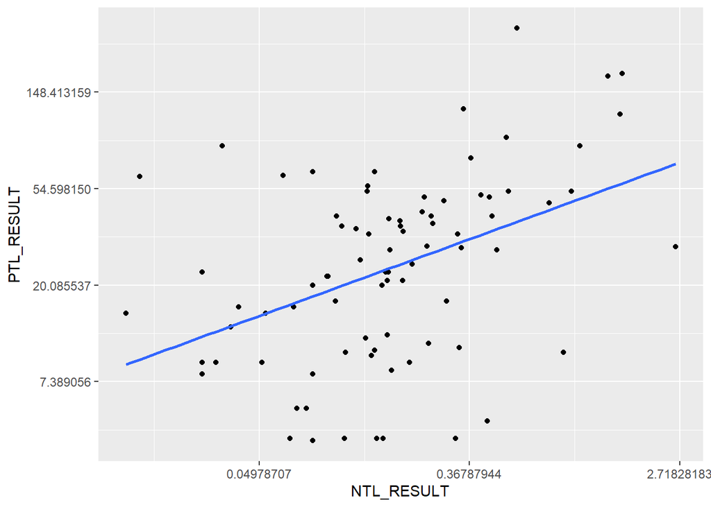

```r
ggplot(data_filtered, aes(x = NTL_RESULT, y = PTL_RESULT)) +
  geom_point() +
  geom_smooth(method='lm', se=FALSE) +
  scale_x_continuous(trans='log') +
  scale_y_continuous(trans='log')
```

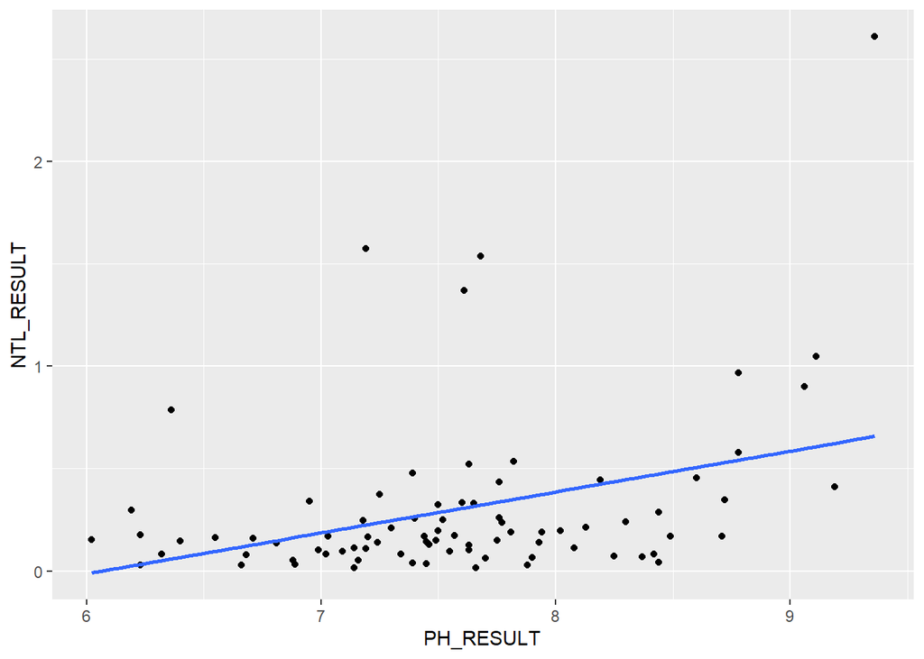

```r
ggplot(data_filtered, aes(x = PH_RESULT, y = NTL_RESULT)) +
  geom_point() +
  geom_smooth(method='lm', se=FALSE)
```

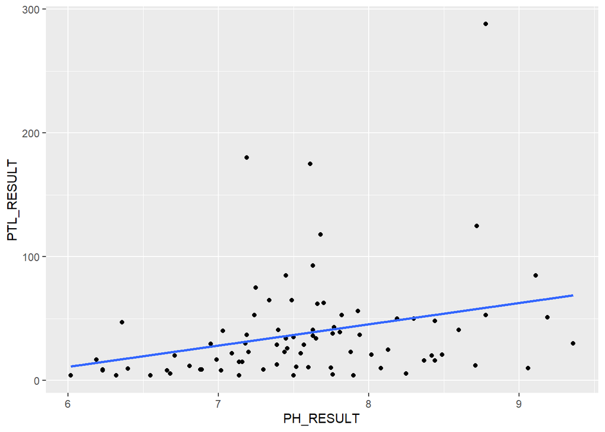

```r
ggplot(data_filtered, aes(x = PH_RESULT, y = PTL_RESULT)) +
  geom_point() +
  geom_smooth(method='lm', se=FALSE)
```

This is a linear regression for phosphorus~nitrogen and phosphorus~pH.

```r
summary(lm(log(PTL_RESULT)~log(NTL_RESULT), data = data_filtered))
```

```
##
## Call:
## lm(formula = log(PTL_RESULT) ~ log(NTL_RESULT), data = data_filtered)
##
## Residuals:
##     Min      1Q  Median      3Q     Max
## -2.0123 -0.6133  0.1017  0.5289  2.0068
##
## Coefficients:
##                 Estimate Std. Error t value Pr(>|t|)
## (Intercept)      3.87436    0.19414   19.96  < 2e-16 ***
## log(NTL_RESULT)  0.39801    0.09521    4.18 7.39e-05 ***
## ---
## Signif. codes:  0 '***' 0.001 '**' 0.01 '*' 0.05 '.' 0.1 ' ' 1
##
## Residual standard error: 0.8927 on 80 degrees of freedom
## Multiple R-squared:  0.1793, Adjusted R-squared:  0.169
## F-statistic: 17.47 on 1 and 80 DF,  p-value: 7.389e-05
```

```r
summary(lm(PTL_RESULT~PH_RESULT, data = data_filtered))
```

```
##
## Call:
## lm(formula = PTL_RESULT ~ PH_RESULT, data = data_filtered)
##
## Residuals:
##     Min      1Q  Median      3Q     Max
## -53.536 -20.560  -7.626   2.444 229.255
##
## Coefficients:
##             Estimate Std. Error t value Pr(>|t|)
## (Intercept)   -91.48      48.70  -1.879   0.0639 .
## PH_RESULT      17.11       6.40   2.673   0.0091 **
## ---
## Signif. codes:  0 '***' 0.001 '**' 0.01 '*' 0.05 '.' 0.1 ' ' 1
##
## Residual standard error: 42.49 on 80 degrees of freedom
## Multiple R-squared:  0.08201,    Adjusted R-squared:  0.07053
## F-statistic: 7.147 on 1 and 80 DF,  p-value: 0.009101
```

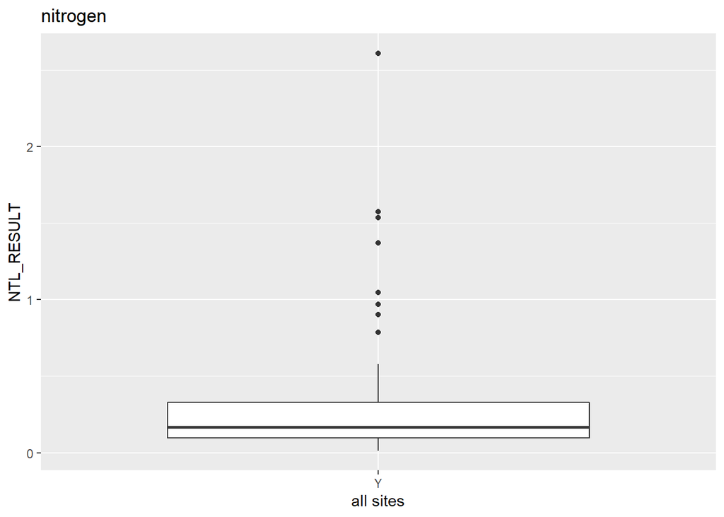

```r
ggplot(data_filtered, aes(x=as.factor(SITESAMP), y=NTL_RESULT)) +
  geom_boxplot()  +
  labs(x="all sites", title = "nitrogen")
```

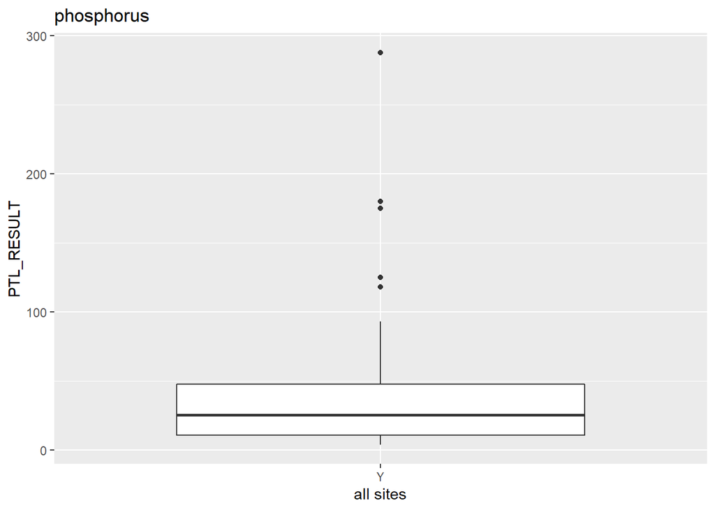

```r
ggplot(data_filtered, aes(x=as.factor(SITESAMP), y=PTL_RESULT)) +
  geom_boxplot()  +
  labs(x="all sites", title = "phosphorus")
```

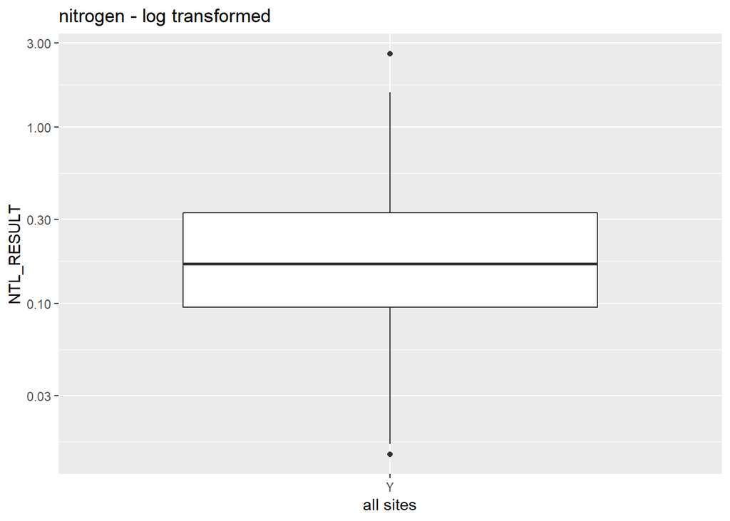

```r
ggplot(data_filtered, aes(x=as.factor(SITESAMP), y=NTL_RESULT)) +
  geom_boxplot()  +
  labs(x="all sites", title = "nitrogen - log transformed") +
  scale_y_continuous(trans='log10')
```

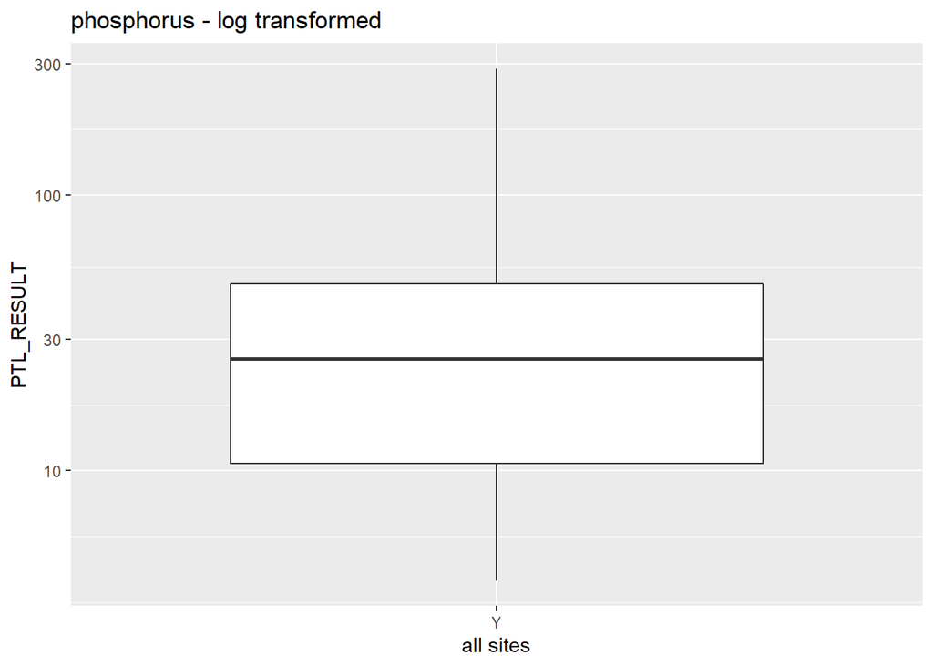

```r
ggplot(data_filtered, aes(x=as.factor(SITESAMP), y=PTL_RESULT)) +
  geom_boxplot()  +
  labs(x="all sites", title = "phosphorus - log transformed") +
  scale_y_continuous(trans='log10')
```

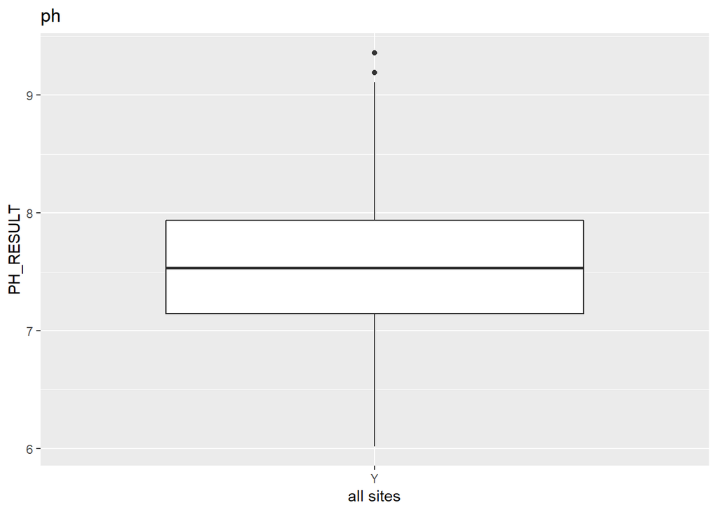

```r
ggplot(data_filtered, aes(x=as.factor(SITESAMP), y=PH_RESULT)) +
  geom_boxplot()  +
  labs(x="all sites", title = "ph")
```

```r
summary(data_filtered)
```

```
##       UID            SITE_ID             VISIT_NO   DATE_COL
##  Min.   :   6559   Length:82          Min.   :1   Length:82
##  1st Qu.:   7259   Class :character   1st Qu.:1   Class :character
##  Median :   7937   Mode  :character   Median :1   Mode  :character
##  Mean   : 152965                      Mean   :1
##  3rd Qu.:   8478                      3rd Qu.:1
##  Max.   :1000194                      Max.   :1
##    SITETYPE           SITESAMP            DSGN12           EVAL_NAME
##  Length:82          Length:82          Length:82          Length:82
##  Class :character   Class :character   Class :character   Class :character
##  Mode  :character   Mode  :character   Mode  :character   Mode  :character
##
##
##
##     STATE             ELEVATION         AREA_HA             PERIM_KM
##  Length:82          Min.   : 108.1   Min.   :    1.033   Min.   :  0.4182
##  Class :character   1st Qu.: 739.4   1st Qu.:    9.804   1st Qu.:  1.4034
##  Mode  :character   Median :1398.7   Median :   21.450   Median :  2.3563
##                     Mean   :1384.7   Mean   :  304.866   Mean   : 12.3257
##                     3rd Qu.:1929.7   3rd Qu.:  119.981   3rd Qu.:  7.3028
##                     Max.   :2732.8   Max.   :11052.354   Max.   :546.2851
##   SIZE_CLASS           FS_EW             NA_L2CODE    NA_L3CODE
##  Length:82          Length:82          Min.   :6.2   Length:82
##  Class :character   Class :character   1st Qu.:6.2   Class :character
##  Mode  :character   Mode  :character   Median :6.2   Mode  :character
##                                        Mean   :6.2
##                                        3rd Qu.:6.2
##                                        Max.   :6.2
##     URBAN           LAKE_ORIGIN        DOMGEOL_BSN
##  Length:82          Length:82          Length:82
##  Class :character   Class :character   Class :character
##  Mode  :character   Mode  :character   Mode  :character
##
##
##
##  NLCD2006_ASSIGNEDAREA_BSN NLCD2006_DEVELOPEDPCT_BSN NLCD2006_FORESTPCT_BSN
##  Min.   :    0.070         Min.   : 0.0000           Min.   : 0.9744
##  1st Qu.:    1.653         1st Qu.: 0.0000           1st Qu.:45.2671
##  Median :    7.803         Median : 0.0000           Median :65.8548
##  Mean   :  253.116         Mean   : 1.5864           Mean   :60.5675
##  3rd Qu.:   52.056         3rd Qu.: 0.8739           3rd Qu.:80.0400
##  Max.   :15523.061         Max.   :58.3435           Max.   :96.6945
##  NLCD2006_IMPERVAREA_BSN   PMEAN_BSN       TMEANPY_BSN        NTL_RESULT
##  Min.   : 0.00000        Min.   : 34253   Min.   : -50.37   Min.   :0.01400
##  1st Qu.: 0.00010        1st Qu.: 86633   1st Qu.: 391.80   1st Qu.:0.09525
##  Median : 0.01047        Median :116180   Median : 572.91   Median :0.16800
##  Mean   : 2.04556        Mean   :127350   Mean   : 580.58   Mean   :0.30065
##  3rd Qu.: 0.11035        3rd Qu.:156946   3rd Qu.: 724.75   3rd Qu.:0.32725
##  Max.   :99.43784        Max.   :324096   Max.   :1205.23   Max.   :2.61000
##    PTL_RESULT       PH_RESULT
##  Min.   :  4.00   Min.   :6.020
##  1st Qu.: 10.62   1st Qu.:7.145
##  Median : 25.50   Median :7.535
##  Mean   : 38.10   Mean   :7.573
##  3rd Qu.: 47.75   3rd Qu.:7.938
##  Max.   :288.00   Max.   :9.360
```

### Establish Gradient

This section sorts data based on the variable of interest: phosphorus.

```r
data_filtered %>%
  dplyr::arrange(PTL_RESULT) -> data_filtered_gradient
  data_filtered_gradient
```

```
## # A tibble: 82 x 28
##      UID SITE_ID      VISIT_NO DATE_COL SITETYPE SITESAMP DSGN12 EVAL_NAME STATE
##    <int> <chr>           <int> <chr>    <chr>    <chr>    <chr>  <chr>     <chr>
##  1  8479 NLA12_OR-173        1 9/11/20~ PROB     Y        Inclu~ Horsesho~ OR
##  2  7916 NLA12_CA-103        1 8/13/20~ PROB     Y        Inclu~ French M~ CA
##  3  7423 NLA12_CA-166        1 7/24/20~ PROB     Y        Inclu~ Eureka L~ CA
##  4  7263 NLA12_CA-167        1 7/18/20~ PROB     Y        Inclu~ Kelly La~ CA
##  5  7366 NLA12_CA-200        1 7/23/20~ PROB     Y        Inclu~ Frog Lake CA
##  6  8779 NLA12_CA-223        1 9/26/20~ PROB     Y        Inclu~ Lake Mary CA
##  7  8483 NLA12_CA-104        1 9/11/20~ PROB     Y        Inclu~ June Lake CA
##  8  7988 NLA12_CA-135        1 8/15/20~ PROB     Y        Inclu~ Caples L~ CA
##  9  8076 NLA12_CA-206        1 8/20/20~ PROB     Y        Inclu~ Shasta L~ CA
## 10  7925 NLA12_MT-140        1 8/14/20~ PROB     Y        Inclu~ Sanders ~ MT
## # ... with 72 more rows, and 19 more variables: ELEVATION <dbl>, AREA_HA <dbl>,
## #   PERIM_KM <dbl>, SIZE_CLASS <chr>, FS_EW <chr>, NA_L2CODE <dbl>,
## #   NA_L3CODE <chr>, URBAN <chr>, LAKE_ORIGIN <chr>, DOMGEOL_BSN <chr>,
## #   NLCD2006_ASSIGNEDAREA_BSN <dbl>, NLCD2006_DEVELOPEDPCT_BSN <dbl>,
## #   NLCD2006_FORESTPCT_BSN <dbl>, NLCD2006_IMPERVAREA_BSN <dbl>,
## #   PMEAN_BSN <dbl>, TMEANPY_BSN <dbl>, NTL_RESULT <dbl>, PTL_RESULT <dbl>,
## #   PH_RESULT <dbl>
```

### PCA

This section is where the PCA is conducted on lake chemistry data.

```r
data_filtered %>%
  dplyr::select(PTL_RESULT, NTL_RESULT, PH_RESULT) %>%
  svd() -> pca_result

pca_result
```

```
## $d
## [1] 527.782692  50.709944   3.243275
##
## $u
##               [,1]         [,2]         [,3]
##  [1,] -0.009003054  0.140224700  0.045900556
##  [2,] -0.010557804  0.143973527  0.078083235
##  [3,] -0.020555147  0.134369214 -0.016467626
##  [4,] -0.119435108  0.041480218 -0.106576900
##  [5,] -0.019384343  0.108733280 -0.008385760
##  [6,] -0.056845606  0.084897733  0.024071201
##  [7,] -0.023038926  0.113450282 -0.015809220
##  [8,] -0.011693199  0.121393263 -0.025853103
##  [9,] -0.021098087  0.130971885  0.040854397
## [10,] -0.008841445  0.121504213  0.002705427
```

[output cut: 78 more lines]